# Expenses Breakdown

Chris

**17/11/2020 Update**

Hey guys have updated this with the last two bills under my name for the transition period when the bills transferreed to David (09/07/2020 - August). There were two additional Electricity Bills with a total of **$238.74** split between three is **$79.58** each.

**Original Post from: 9/7/2020**

Hey Guys,

Heres a breakdown of the power/internet I’ve been paying. Ive got what was debited from me below. I split up the periods of when each of us were living at Sherwood ln (bless), split the amounts evenly and tallied it up for the relevant parties.

Nora paid me power already based off her units, so that was subtracted from the period when we were living together and the rest split between David and I evenly so whats left is for internet.

Have a look through the information and if you see anything off or want to change how anything was calculated let me know!

Anyway based off these calculations these are how much you guys owe me. No rush. Miss you guys and the flat!

At 09/07/2020:

David owed chris $1426.42

Michelle owed chris $365.37

Will owed chris $346.31

Nora owed chris $239.87

# Electricity

### Total Electricity (Final Billls after 9/07/2020)

| Date | Amount | Other.Party |
| --- | --- | --- |
| 2020-07-30 | -118.66 | Electric Kiwi Ltd |
| 2020-07-16 | -120.08 | Electric Kiwi Ltd |

### Total Electricity (Up to 9/07/2020)

| Date | Amount | Other.Party |
| --- | --- | --- |
| 2020-07-02 | -115.95 | Electric Kiwi Ltd |
| 2020-06-18 | -106.07 | Electric Kiwi Ltd |
| 2020-06-05 | -93.25 | Electric Kiwi Ltd |
| 2020-05-21 | -84.99 | Electric Kiwi Ltd |
| 2020-05-07 | -78.57 | Electric Kiwi Ltd |
| 2020-04-23 | -91.90 | Electric Kiwi Ltd |
| 2020-04-09 | -91.93 | Electric Kiwi Ltd |
| 2020-03-26 | -58.87 | Electric Kiwi Ltd |
| 2020-03-12 | -47.55 | Electric Kiwi Ltd |
| 2020-02-27 | -51.89 | Electric Kiwi Ltd |
| 2020-02-13 | -46.57 | Electric Kiwi Ltd |
| 2020-01-30 | -48.66 | Electric Kiwi Ltd |
| 2020-01-16 | -47.45 | Electric Kiwi Ltd |
| 2020-01-03 | -46.92 | Electric Kiwi Ltd |
| 2019-12-19 | -43.11 | Electric Kiwi Ltd |
| 2019-12-05 | -47.97 | Electric Kiwi Ltd |
| 2019-11-21 | -49.87 | Electric Kiwi Ltd |
| 2019-11-07 | -61.11 | Electric Kiwi Ltd |
| 2019-10-24 | -64.42 | Electric Kiwi Ltd |
| 2019-10-10 | -44.92 | Electric Kiwi Ltd |
| 2019-09-26 | -33.01 | Electric Kiwi Ltd |
| 2019-09-12 | -54.45 | Electric Kiwi Ltd |
| 2019-08-29 | -97.01 | Electric Kiwi Ltd |
| 2019-08-15 | -132.59 | Electric Kiwi Ltd |
| 2019-08-01 | -108.57 | Electric Kiwi Ltd |
| 2019-07-18 | -69.96 | Electric Kiwi Ltd |
| 2019-07-04 | -103.14 | Electric Kiwi Ltd |
| 2019-06-20 | -89.83 | Electric Kiwi Ltd |
| 2019-06-06 | -57.47 | Electric Kiwi Ltd |
| 2019-05-23 | -54.98 | Electric Kiwi Ltd |
| 2019-05-09 | -39.78 | Electric Kiwi Ltd |
| 2019-04-26 | -49.59 | Electric Kiwi Ltd |
| 2019-04-11 | -48.60 | Electric Kiwi Ltd |
| 2019-03-28 | -37.44 | Electric Kiwi Ltd |
| 2019-03-14 | -33.05 | Electric Kiwi Ltd |
| 2019-02-28 | -44.99 | Electric Kiwi Ltd |
| 2019-02-14 | -49.55 | Electric Kiwi Ltd |

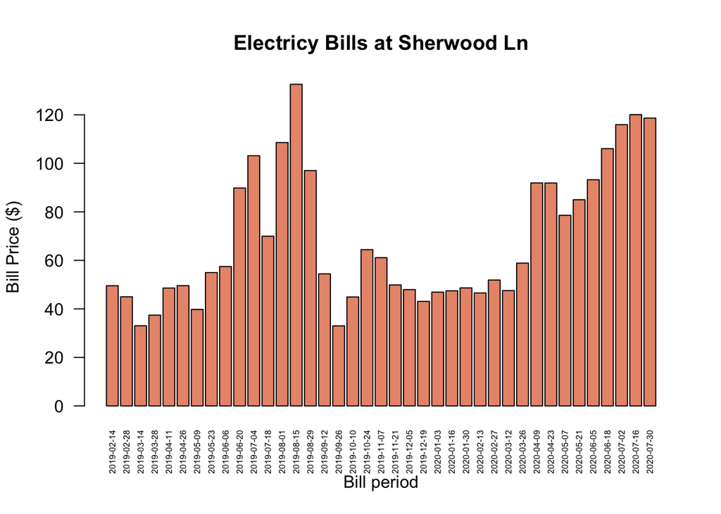

### Electricity Period before Nora

| Date | Amount | Other.Party |
| --- | --- | --- |
| 2019-05-09 | -39.78 | Electric Kiwi Ltd |
| 2019-04-26 | -49.59 | Electric Kiwi Ltd |
| 2019-04-11 | -48.60 | Electric Kiwi Ltd |
| 2019-03-28 | -37.44 | Electric Kiwi Ltd |
| 2019-03-14 | -33.05 | Electric Kiwi Ltd |
| 2019-02-28 | -44.99 | Electric Kiwi Ltd |

```
## [1] "Total Power before Nora = $253.45"
```

```
## [1] "Split between 2 = $126.72 each."
```

```
## [1] "David & Chris"
```

### Electricity Period With Nora

| Date | Amount | Other.Party |
| --- | --- | --- |
| 2020-01-16 | -47.45 | Electric Kiwi Ltd |
| 2020-01-03 | -46.92 | Electric Kiwi Ltd |
| 2019-12-19 | -43.11 | Electric Kiwi Ltd |
| 2019-12-05 | -47.97 | Electric Kiwi Ltd |
| 2019-11-21 | -49.87 | Electric Kiwi Ltd |
| 2019-11-07 | -61.11 | Electric Kiwi Ltd |
| 2019-10-24 | -64.42 | Electric Kiwi Ltd |
| 2019-10-10 | -44.92 | Electric Kiwi Ltd |
| 2019-09-26 | -33.01 | Electric Kiwi Ltd |
| 2019-09-12 | -54.45 | Electric Kiwi Ltd |
| 2019-08-29 | -97.01 | Electric Kiwi Ltd |
| 2019-08-15 | -132.59 | Electric Kiwi Ltd |
| 2019-08-01 | -108.57 | Electric Kiwi Ltd |
| 2019-07-18 | -69.96 | Electric Kiwi Ltd |
| 2019-07-04 | -103.14 | Electric Kiwi Ltd |
| 2019-06-20 | -89.83 | Electric Kiwi Ltd |
| 2019-06-06 | -57.47 | Electric Kiwi Ltd |
| 2019-05-23 | -54.98 | Electric Kiwi Ltd |

```
## [1] "Total power for period with Nora $1206.78"
```

```
## [1] "Nora Paid $217.61"
```

```
## [1] "Total minus what Nora Paid $989.17"
```

```
## [1] "Split between 2 = $494.58 each."
```

```
## [1] "David, Chris & Nora"
```

### Electricity Period With Michelle

| Date | Amount | Other.Party |
| --- | --- | --- |
| 2020-02-27 | -51.89 | Electric Kiwi Ltd |
| 2020-02-13 | -46.57 | Electric Kiwi Ltd |
| 2020-01-30 | -48.66 | Electric Kiwi Ltd |

```
## [1] "Total power for period with Michelle $147.12"
```

```
## [1] "Split between 3 = $49.04 each"
```

```
## [1] "David, Chris & Michelle"
```

### Electricity Period with Will/without Chris

| Date | Amount | Other.Party |
| --- | --- | --- |
| 2020-07-02 | -115.95 | Electric Kiwi Ltd |
| 2020-06-18 | -106.07 | Electric Kiwi Ltd |
| 2020-06-05 | -93.25 | Electric Kiwi Ltd |
| 2020-05-21 | -84.99 | Electric Kiwi Ltd |
| 2020-05-07 | -78.57 | Electric Kiwi Ltd |
| 2020-04-23 | -91.90 | Electric Kiwi Ltd |
| 2020-04-09 | -91.93 | Electric Kiwi Ltd |
| 2020-03-26 | -58.87 | Electric Kiwi Ltd |
| 2020-03-12 | -47.55 | Electric Kiwi Ltd |

```
## [1] "Total power for period without Chris $769.08"
```

[output not shown]

```
## [1] "David, Will & Michelle"
```

# Internet

### Total Internet

| Process.Date | Amount | Other.Party |
| --- | --- | --- |
| 2019-01-29 | -39.95 | FLIP SERVICES LTD AUCKLAND NZL |
| 2019-03-04 | -89.95 | FLIP SERVICES LTD AUCKLAND NZL |
| 2019-04-02 | -89.95 | FLIP SERVICES LTD AUCKLAND NZL |
| 2019-05-02 | -89.95 | FLIP SERVICES LTD AUCKLAND NZL |
| 2019-06-04 | -89.95 | FLIP SERVICES LTD AUCKLAND NZL |
| 2019-07-02 | -89.95 | FLIP SERVICES LTD AUCKLAND NZL |
| 2019-08-02 | -89.95 | FLIP SERVICES LTD AUCKLAND NZL |
| 2019-09-02 | -89.95 | FLIP SERVICES LTD AUCKLAND NZL |
| 2019-10-02 | -89.95 | FLIP SERVICES LTD AUCKLAND NZL |
| 2019-11-04 | -89.95 | FLIP SERVICES LTD AUCKLAND NZL |
| 2019-12-02 | -89.95 | FLIP SERVICES LTD AUCKLAND NZL |
| 2020-01-03 | -89.95 | FLIP SERVICES LTD AUCKLAND NZL |
| 2020-02-03 | -89.95 | FLIP SERVICES LTD AUCKLAND NZL |
| 2020-03-02 | -89.95 | FLIP SERVICES LTD AUCKLAND NZL |
| 2020-04-02 | -89.95 | FLIP SERVICES LTD AUCKLAND NZL |
| 2020-05-04 | -89.95 | FLIP SERVICES LTD AUCKLAND NZL |

### Internet Before Nora

| Process.Date | Amount | Other.Party |
| --- | --- | --- |
| 2019-01-29 | -39.95 | FLIP SERVICES LTD AUCKLAND NZL |
| 2019-03-04 | -89.95 | FLIP SERVICES LTD AUCKLAND NZL |
| 2019-04-02 | -89.95 | FLIP SERVICES LTD AUCKLAND NZL |
| 2019-05-02 | -89.95 | FLIP SERVICES LTD AUCKLAND NZL |
| 2019-06-04 | -89.95 | FLIP SERVICES LTD AUCKLAND NZL |

```
## [1] "Total internet for period before Nora $399.75"
```

```
## [1] "Split between 2 = $199.875 each."
```

```
## [1] "David & Chris"
```

### Internet With Nora

| Process.Date | Amount | Other.Party |
| --- | --- | --- |
| 2019-07-02 | -89.95 | FLIP SERVICES LTD AUCKLAND NZL |
| 2019-08-02 | -89.95 | FLIP SERVICES LTD AUCKLAND NZL |
| 2019-09-02 | -89.95 | FLIP SERVICES LTD AUCKLAND NZL |
| 2019-10-02 | -89.95 | FLIP SERVICES LTD AUCKLAND NZL |
| 2019-11-04 | -89.95 | FLIP SERVICES LTD AUCKLAND NZL |
| 2019-12-02 | -89.95 | FLIP SERVICES LTD AUCKLAND NZL |
| 2020-01-03 | -89.95 | FLIP SERVICES LTD AUCKLAND NZL |
| 2020-02-03 | -89.95 | FLIP SERVICES LTD AUCKLAND NZL |

```
## [1] "Total internet for period with Nora $719.6"
```

```
## [1] "Split between 3 = $239.87 each."
```

```
## [1] "David, Chris & Nora"
```

### Internet With Michelle

| Process.Date | Amount | Other.Party |
| --- | --- | --- |
| 2020-03-02 | -89.95 | FLIP SERVICES LTD AUCKLAND NZL |

```
## [1] "Total internet for period with Michelle $89.95"
```

```
## [1] "Split between 3  = $29.98 each."
```

```
## [1] "David, Chris & Michelle"
```

### Internet With Will/Without Chris

| Process.Date | Amount | Other.Party |
| --- | --- | --- |
| 2020-04-02 | -89.95 | FLIP SERVICES LTD AUCKLAND NZL |
| 2020-05-04 | -89.95 | FLIP SERVICES LTD AUCKLAND NZL |

[output not shown]

[output not shown]

```
## [1] "David, Will & Michelle"
```

# Totals - 09/07/2020

```
## [1] "David owes chris $1426.42"
```

```
## [1] "Michelle owes chris $365.37"
```

```
## [1] "Will owes chris $346.31"
```

```
## [1] "Nora owes chris $239.87"
```

# Totals - 17/11/2020

```r
electricNew <- electricNew[order(electricNew$Date, decreasing = T),]

newPowerTotal <-  sum(electricNew[c(0:2),]$Amount)
paste("New power total $", round(newPowerTotal*-1,2), sep = "")
```

```
## [1] "New power total $238.74"
```

```r
paste("Split Between 3 $", newPowerTotal/3*-1, sep = "")
```

```
## [1] "Split Between 3 $79.58"
```